# Coursework - SML

Anton Cronet (224220895), Erik Füßlein (220241605)

### Introduction

- Identify and formulate a regression **or** a classification problem of interest to you that calls for a data-driven answer. You can start with your domain-specific interests or by looking for an interesting dataset.
- Aim for at least 5 input variables.
- Explain your variables briefly

### Description

- Collect your dataset(s), explore your data for deficiencies such as missing data and formatting problems and prepare it for modelling.
- Extensive data collection and preparation yields extra credit but is not mandatory for this coursework.
- Explore the data via descriptive statistics and visualization.

# Data Processing

## Further preparation for more complex models

```r
df <- data_final_aggr
names(df) # Print variables

###################################################


df <- df[sample(nrow(df), size = floor(0.25 * nrow(df))), ]  # influences model run time a lot

# I removed a part of the data, else the models take too long to run
###################################################

set.seed(123)  # for reproducibility
n <- nrow(df)
train_index <- sample(seq_len(n), size = 0.8 * n)

train <- df[train_index, ]
test  <- df[-train_index, ]
```

### Models 1 & 2

- Use at least two different models to investigate your regression or classification problem. Both models receive the same input variables.
- If you tune your model/s for some metric, only use the final tuned version of your model in the comparison.
- Evaluate and compare your models based on a reasonable evaluation metric of your choice. You must use the same metric for both models. Report both the training and the CV loss.

# Tree Model

```r
library(rpart)

# Initial model
model <- rpart(Bikes_Counted ~ . - Date_Hour, data = train, method = "anova", cp = 0, maxdepth = 5)
# depth = 5 keeps training and cv loss close, without having them both be increased. It. also makes the cp plot visually readable

# 10-fold cross-validation is apparently default in rpart package, anova uses mse for cv
plotcp(model)
best_cp <- model$cptable[which.min(model$cptable[, "xerror"]), "CP"]
best_cp

# Prune the tree
pruned_model <- prune(model, cp = best_cp)

# Predict on test set
pred <- predict(pruned_model, newdata = test)

# True values
actual <- test$Bikes_Counted

# Metrics
mae <- mean(abs(pred - actual))
rmse <- sqrt(mean((pred - actual)^2))
r2 <- 1 - sum((actual - pred)^2) / sum((actual - mean(actual))^2)

# Output metrics
metrics_tree <- c(MAE = mae, RMSE = rmse, R2 = r2)

# Training MSE
train_pred <- predict(pruned_model, newdata = train)
train_actual <- train$Bikes_Counted
training_mse <- mean((train_actual - train_pred)^2)

# CV MSE (from xerror * RSS in cptable, divide by nrow(train))
cv_mse <- min(model$cptable[, "xerror"]) * mean((train_actual - mean(train_actual))^2)

# Output MSE losses
losses_tree <- c(Training_MSE = training_mse, CV_MSE = cv_mse)
losses_tree
```

[output not shown]

### Ensemble

- Repeat the analysis using two ensemble methods.
- Investigate the hyperparameter settings of your ensembles with regards to your evaluation metric.
- Report both the training and the CV loss.
- Select the best configurations of your ensemble models based on the same evaluation metric as before.

# Ensemble 1: Random Forest

```r
library(randomForest)
library(caret)

# Remove Date_Hour
train_data <- train[, !(names(train) %in% c("Date_Hour"))]

# Tune mtry with OOB error
x <- train_data[, -which(names(train_data) == "Bikes_Counted")]
y <- train_data$Bikes_Counted

best_mtry <- tuneRF(
  x = x,
  y = y,
  mtryStart = 5,
  stepFactor = 1.5,
  improve = 0.05,
  ntreeTry = 50,
  trace = TRUE,
  plot = TRUE
)
optimal_mtry <- best_mtry[which.min(best_mtry[, "OOBError"]), "mtry"]

# Set up 5-fold cross-validation
ctrl <- trainControl(method = "cv", number = 5)

# Train model with cross-validation
model_cv <- train(
  Bikes_Counted ~ .,
  data = train_data,
  method = "rf",
  trControl = ctrl,
  tuneGrid = data.frame(mtry = optimal_mtry),
  ntree = 100,
  importance = TRUE
)

# Extract CV metrics
cv_mse <- model_cv$results$RMSE^2
cv_mae <- model_cv$results$MAE
cv_r2 <- model_cv$results$Rsquared

metrics_cv <- c(MAE = cv_mae, RMSE = sqrt(cv_mse), R2 = cv_r2, MSE = cv_mse)

# Fit final model
model <- randomForest(Bikes_Counted ~ ., data = train_data, ntree = 100, mtry = optimal_mtry, importance = TRUE)

# Training metrics
train_pred <- predict(model, newdata = train_data)
training_mse <- mean((train_data$Bikes_Counted - train_pred)^2)

# Test set predictions
test_data <- test[, !(names(test) %in% c("Date_Hour", "Bikes_Counted"))]
pred <- predict(model, newdata = test_data)
actual <- test$Bikes_Counted

# Test metrics
mae <- mean(abs(pred - actual))
rmse <- sqrt(mean((pred - actual)^2))
r2 <- 1 - sum((actual - pred)^2) / sum((actual - mean(actual))^2)

metrics_ens1 <- c(MAE = mae, RMSE = rmse, R2 = r2)
losses_rf <- c(Training_MSE = training_mse, CV_MSE = cv_mse)
```

# Ensemble 2: Gradient Boosting

Note: gbm package does parallel compute (all CPU cores) - can go heavy on the hyperparameters

```r
# install.packages("gbm")
library(gbm)

train_data <- train[, !(names(train) %in% c("Date_Hour"))]
test_data <- test[, !(names(test) %in% c("Date_Hour", "Bikes_Counted"))]

set.seed(123)
model_gbm <- gbm(
  Bikes_Counted ~ .,
  data = train_data,
  distribution = "gaussian",
  n.trees = 400,
  interaction.depth = 2,
  shrinkage = 0.05,
  cv.folds = 20
)

best_iter <- gbm.perf(model_gbm, method = "cv", plot.it = FALSE) # Plot is made later with legend

pred <- predict(model_gbm, newdata = test_data, n.trees = best_iter)
actual <- test$Bikes_Counted

mae <- mean(abs(pred - actual))
rmse <- sqrt(mean((pred - actual)^2))
r2 <- 1 - sum((actual - pred)^2) / sum((actual - mean(actual))^2)

metrics_ens2 <- c(MAE = mae, RMSE = rmse, R2 = r2)


# Training loss (MSE) at each iteration
train_loss <- model_gbm$train.error

# Validation loss (CV MSE) at each iteration
val_loss <- model_gbm$cv.error

# Plot both losses
plot(train_loss, type = "l", col = "grey", lwd = 2, ylab = "MSE", xlab = "Number of Trees")
lines(val_loss, col = "orange", lwd = 2)
legend("topright", legend = c("Training MSE", "CV MSE"), col = c("grey", "orange"), lwd = 2)
```

### Neural Network

- Repeat the analysis with a neural network.
- Investigate three different configurations with regards to your evaluation metric and select the best configuration. Use the same evaluation metric as before.
- Report both the training and the CV loss.

```r
library(keras)
library(dplyr)
library(recipes)
library(tensorflow)
library(reticulate)


# Remove unused columns
train_data <- train %>% select(-Date_Hour)
test_data <- test %>% select(-Date_Hour, -Bikes_Counted)

# Define preprocessing using `recipes`
rec <- recipe(Bikes_Counted ~ ., data = train_data) %>%
  step_dummy(all_nominal_predictors()) %>%      # one-hot encode categoricals
  step_center(all_numeric_predictors()) %>%
  step_scale(all_numeric_predictors()) %>%
  prep()

# Apply preprocessing
x_train <- bake(rec, new_data = train_data) %>% select(-Bikes_Counted) %>% as.matrix()
x_test <- bake(rec, new_data = test_data) %>% as.matrix()

y_train <- train_data$Bikes_Counted
y_test <- test$Bikes_Counted

# Build Keras model
model <- keras_model_sequential() %>%
  layer_dense(units = 32, activation = "relu", input_shape = ncol(x_train)) %>%
  layer_dropout(rate = 0.2) %>% # The key to reduce overfitting
  layer_dense(units = 16, activation = "relu") %>%
  layer_dense(units = 1)

model %>% compile(
  loss = "mse",
  optimizer = optimizer_adam(),
  metrics = list("mae")
)

# Train model
history <- model %>% fit(
  x_train, y_train,
  epochs = 50, # Afterwhich it starts to overfit, and so extra gain for validation loss
  batch_size = 32,
  validation_split = 0.2,
  verbose = 0
)

plot(history) # Avoids per-epoch output, but keeps loss plot


# Predict + evaluate
pred <- model %>% predict(x_test) %>% as.vector()

mae <- mean(abs(pred - y_test))
rmse <- sqrt(mean((pred - y_test)^2))
r2 <- 1 - sum((y_test - pred)^2) / sum((y_test - mean(y_test))^2)

metrics_nn <- c(MAE = mae, RMSE = rmse, R2 = r2)
```

### Model Comparison

- Compare the performance of the 5 models.

```r
# Combine all metric vectors into a list
metrics_list <- list(
  lm = metrics_lm,
  tree = metrics_tree,
  ens1 = metrics_ens1,
  ens2 = metrics_ens2,
  nn = metrics_nn
)

# Convert to data frame
metrics_df <- do.call(rbind, metrics_list)

# Add model names as a column
metrics_df <- data.frame(Model = rownames(metrics_df), metrics_df, row.names = NULL)

# Print nicely
print(metrics_df)

# Optional: pretty table
library(knitr)
kable(metrics_df, digits = 3, caption = "Model Performance Metrics")
```

[output not shown]

### PCA

- Run a PCA on your input variables and discuss the scope for dimensionality reduction in your dataset.
- Rerun the previous 5 models on all PCs or on a reduced number of PCs.

```r
clean_df <- na.omit(df) # Neede for running PCA

# Basic PCA
pca <- prcomp(clean_df[ , !(names(df) %in% c("Date_Hour","precip_type","cloud_cover","Hour","Weekday","Holiday","School_holidays","wind_dir","Month"))], scale. = TRUE)


# View results
summary(pca)       # Variance explained
```

```
Importance of components:
                          PC1    PC2    PC3    PC4     PC5     PC6     PC7
Standard deviation     1.7346 1.4717 1.0288 1.0192 0.92810 0.84905 0.66489
Proportion of Variance 0.3009 0.2166 0.1058 0.1039 0.08614 0.07209 0.04421
Cumulative Proportion  0.3009 0.5175 0.6233 0.7272 0.81334 0.88543 0.92963
                           PC8     PC9    PC10
Standard deviation     0.62732 0.49986 0.24550
Proportion of Variance 0.03935 0.02499 0.00603
Cumulative Proportion  0.96899 0.99397 1.00000
```

```r
pca$rotation       # Loadings
```

```
                            PC1          PC2         PC3         PC4
Bikes_Counted       -0.41327704  0.170153594  0.09870471 -0.30207529
visibility          -0.35365108  0.003259534 -0.10270621  0.44405641
air_pressure         0.02658738  0.419541076  0.25292055 -0.03750829
rel_humidity         0.50761541 -0.055007317 -0.11298505 -0.03561098
air_temp            -0.42029970  0.096361336 -0.30718459 -0.04968420
sunshine_duration   -0.43212163  0.174442371  0.16915992 -0.26360577
precip_h_mm          0.07466420 -0.164338457 -0.37060613 -0.76273978
wind_highest_last_h -0.19944020 -0.599155496  0.12540485 -0.02186611
wind_speed          -0.16398203 -0.604792657  0.16023656  0.04816121
snow_cover_cm        0.10065051 -0.022635573  0.77540048 -0.22883025
                            PC5         PC6        PC7         PC8
Bikes_Counted        0.13504537  0.32271487 -0.1146586 -0.75031475
visibility          -0.36845672 -0.52084992 -0.3348375 -0.24511708
air_pressure         0.53061779 -0.58924356  0.3337650 -0.08350086
rel_humidity         0.03878897  0.16618192  0.0335374 -0.24477570
air_temp            -0.29176461  0.10620093  0.7487396  0.10487425
sunshine_duration    0.17928999  0.14544538 -0.3717028  0.54396187
precip_h_mm         -0.16336173 -0.44758051 -0.1246548 -0.02045782
wind_highest_last_h  0.22378212 -0.09002793  0.1050643 -0.03101818
wind_speed           0.24921711 -0.06360016  0.1310376 -0.03745197
snow_cover_cm       -0.55389206 -0.06953236  0.1403258 -0.01953047
                            PC9         PC10
Bikes_Counted       -0.02295690 -0.015158024
visibility           0.29649023  0.005971454
air_pressure         0.10278239  0.014276149
rel_humidity         0.79474084  0.059102634
air_temp             0.22184309  0.001612514
sunshine_duration    0.44427370  0.001349515
precip_h_mm         -0.04091258 -0.060421007
wind_highest_last_h  0.04341755  0.716214089
wind_speed           0.12337737 -0.692380574
snow_cover_cm        0.06336350  0.005389575
```

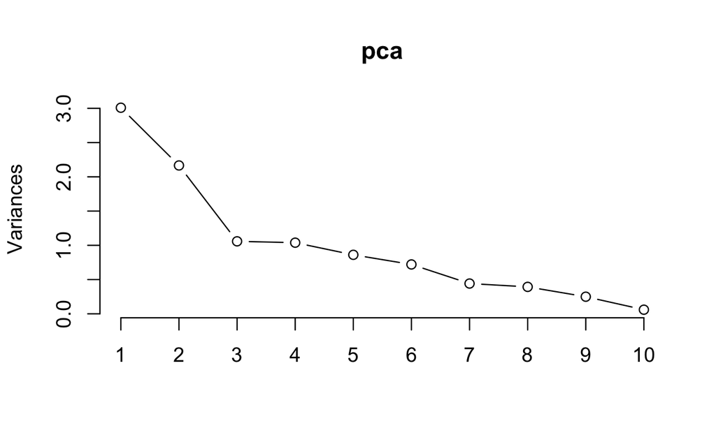

```r
#  pca$x           # Principal components (scores)

# Scree plot
plot(pca, type = "l")
```

```r
# Biplot
# biplot(pca) # Takes a long time to run, very crowded plot

# 3 PCs chosen according to scree plot
train_pca <- as.data.frame(pca$x[, 1:3])


# Select same columns used in PCA
pca_vars <- names(clean_df)[ !(names(clean_df) %in% c("Date_Hour","precip_type","cloud_cover","Hour","Weekday","Holiday","School_holidays","wind_dir","Month")) ]

# Center and scale test set using training PCA parameters
test_scaled <- scale(test[, pca_vars], center = pca$center, scale = pca$scale)

# Apply PCA rotation (dot product)
test_pca <- as.data.frame(test_scaled %*% pca$rotation[, 1:3])


train_pca$Bikes_Counted <- clean_df$Bikes_Counted
test_pca$Bikes_Counted <- test$Bikes_Counted
```

# Linear Regreession (PCA). # Draft model

```r
set.seed(123)

# Prepare folds
folds <- sample(rep(1:5, length.out = nrow(train_pca)))

cv_mse <- numeric(5)

for (k in 1:5) {
  train_fold <- train_pca[folds != k, ]
  val_fold <- train_pca[folds == k, ]

  lm_fit <- lm(Bikes_Counted ~ ., data = train_fold)
  val_pred <- predict(lm_fit, newdata = val_fold)

  cv_mse[k] <- mean((val_fold$Bikes_Counted - val_pred)^2)
}

cv_mse_mean <- mean(cv_mse)

# Train final model on all training data
final_lm <- lm(Bikes_Counted ~ ., data = train_pca)

# Predict on test set
test_pred <- predict(final_lm, newdata = test_pca)
actual_test <- test_pca$Bikes_Counted

# Metrics on test set
mae_test <- mean(abs(test_pred - actual_test))
rmse_test <- sqrt(mean((test_pred - actual_test)^2))
r2_test <- 1 - sum((actual_test - test_pred)^2) / sum((actual_test - mean(actual_test))^2)

# Training MSE
train_pred <- predict(final_lm, newdata = train_pca)
training_mse <- mean((train_pca$Bikes_Counted - train_pred)^2)

list(
  Test_Metrics = c(MAE = mae_test, RMSE = rmse_test, R2 = r2_test),
  Training_MSE = training_mse,
  CV_MSE = cv_mse_mean
)
```

# Tree Model (PCA)

```r
library(rpart)

# Train initial tree model on PCA-transformed training data
model_pca <- rpart(Bikes_Counted ~ ., data = train_pca, method = "anova", cp = 0, maxdepth = 5)
# maxdepth = 5 good balance between training - cv loss gap while not having both increase

# Use cross-validation info to find optimal cp
best_cp_pca <- model_pca$cptable[which.min(model_pca$cptable[, "xerror"]), "CP"]

# Prune the tree
pruned_model_pca <- prune(model_pca, cp = best_cp_pca)

# Predict on PCA-transformed test data
pred_pca <- predict(pruned_model_pca, newdata = test_pca)

# True values
actual_pca <- test_pca$Bikes_Counted

# Metrics
mae_pca <- mean(abs(pred_pca - actual_pca))
rmse_pca <- sqrt(mean((pred_pca - actual_pca)^2))
r2_pca <- 1 - sum((actual_pca - pred_pca)^2) / sum((actual_pca - mean(actual_pca))^2)
metrics_tree_pca <- c(MAE = mae_pca, RMSE = rmse_pca, R2 = r2_pca)

# Training MSE
train_pred_pca <- predict(pruned_model_pca, newdata = train_pca)
train_actual_pca <- train_pca$Bikes_Counted
training_mse_pca <- mean((train_actual_pca - train_pred_pca)^2)

# CV MSE (xerror * variance of response)
cv_mse_pca <- min(model_pca$cptable[, "xerror"]) * var(train_actual_pca)

# Output MSE losses
losses_tree_pca <- c(Training_MSE = training_mse_pca, CV_MSE = cv_mse_pca)
losses_tree_pca
```

# Ensemble 1: Random Forest (PCA)

```r
library(randomForest)
library(caret)

## --- Tune mtry on PCA features (OOB) ----
x_pca <- train_pca[, -which(names(train_pca) == "Bikes_Counted")]
y_pca <- train_pca$Bikes_Counted

set.seed(42)
best_mtry_pca <- tuneRF(
  x          = x_pca,
  y          = y_pca,
  mtryStart  = 3,           # adjust if you like
  stepFactor = 1.5,
  improve    = 0.05,
  ntreeTry   = 50,
  trace      = TRUE,
  plot       = TRUE
)
optimal_mtry <- best_mtry_pca[which.min(best_mtry_pca[, "OOBError"]), "mtry"]

## --- 5‑fold cross‑validation with caret ----
ctrl <- trainControl(method = "cv", number = 5, savePredictions = "final")

set.seed(42)
rf_pca_cv <- train(
  Bikes_Counted ~ .,
  data      = train_pca,
  method    = "rf",
  trControl = ctrl,
  tuneGrid  = data.frame(mtry = optimal_mtry),
  ntree     = 100,
  importance = TRUE
)

## --- Metrics ----
cv_rmse <- rf_pca_cv$results$RMSE
cv_mae  <- rf_pca_cv$results$MAE
cv_mse  <- cv_rmse^2

rf_pca  <- rf_pca_cv$finalModel           # fitted on full data

# Training set
train_preds <- predict(rf_pca, newdata = train_pca)
training_mse_pca <- mean((train_pca$Bikes_Counted - train_preds)^2)

# Test set
preds   <- predict(rf_pca, newdata = test_pca)
actuals <- test_pca$Bikes_Counted

mae  <- mean(abs(preds - actuals))
rmse <- sqrt(mean((preds - actuals)^2))
r2   <- 1 - sum((actuals - preds)^2) / sum((actuals - mean(actuals))^2)

## --- Outputs ----
metrics_ens1_pca <- c(MAE = mae,  RMSE = rmse,  R2 = r2)
losses_rf_pca    <- c(Training_MSE = training_mse_pca, CV_MSE = cv_mse)
```

# Ensemble 2: Gradient Boosting (PCA)

```r
library(gbm)

# Use PCA-transformed training and test data
train_data_pca <- train_pca
test_data_pca <- test_pca[, -which(names(test_pca) == "Bikes_Counted")]

set.seed(123)
model_gbm_pca <- gbm(
  Bikes_Counted ~ .,
  data = train_data_pca,
  distribution = "gaussian",
  n.trees = 200,
  interaction.depth = 2,
  shrinkage = 0.05,
  cv.folds = 15
)

# Best number of trees based on CV
best_iter_pca <- gbm.perf(model_gbm_pca, method = "cv", plot.it = FALSE)

# Predict on test set
pred_pca <- predict(model_gbm_pca, newdata = test_data_pca, n.trees = best_iter_pca)
actual_pca <- test_pca$Bikes_Counted

# Evaluation metrics
mae_pca <- mean(abs(pred_pca - actual_pca))
rmse_pca <- sqrt(mean((pred_pca - actual_pca)^2))
r2_pca <- 1 - sum((actual_pca - pred_pca)^2) / sum((actual_pca - mean(actual_pca))^2)

# Store test metrics
metrics_ens2_pca <- c(MAE = mae_pca, RMSE = rmse_pca, R2 = r2_pca)

# Training and CV loss over iterations
train_loss_pca <- model_gbm_pca$train.error
val_loss_pca <- model_gbm_pca$cv.error

# Plot training and validation MSE
plot(train_loss_pca, type = "l", col = "grey", lwd = 2, ylab = "MSE", xlab = "Number of Trees")
lines(val_loss_pca, col = "orange", lwd = 2)
legend("topright", legend = c("Training MSE", "CV MSE"), col = c("grey", "orange"), lwd = 2)

# Store selected losses
losses_gbm_pca <- c(Training_MSE = train_loss_pca[best_iter_pca], CV_MSE = val_loss_pca[best_iter_pca])
```

# Neural Network (PCA)

```r
library(keras)

# Prepare PCA-based training and test matrices
x_train_pca <- train_pca[, -which(names(train_pca) == "Bikes_Counted")] %>% as.matrix()
x_test_pca <- test_pca[, -which(names(test_pca) == "Bikes_Counted")] %>% as.matrix()

y_train_pca <- train_pca$Bikes_Counted
y_test_pca <- test_pca$Bikes_Counted

# Build Keras model
model_pca <- keras_model_sequential() %>%
  layer_dense(units = 32, activation = "relu", input_shape = ncol(x_train_pca)) %>%
  layer_dropout(rate = 0.2) %>% # The key to reduce overfitting
  layer_dense(units = 16, activation = "relu") %>%
  layer_dense(units = 1)

model_pca %>% compile(
  loss = "mse",
  optimizer = optimizer_adam(),
  metrics = list("mae")
)

# Train model
history_pca <- model_pca %>% fit(
  x_train_pca, y_train_pca,
  epochs = 200,
  batch_size = 16,
  validation_split = 0.2,
  verbose = 0
)

plot(history_pca)


# Predict and evaluate
pred_pca <- model_pca %>% predict(x_test_pca) %>% as.vector()

mae_pca <- mean(abs(pred_pca - y_test_pca))
rmse_pca <- sqrt(mean((pred_pca - y_test_pca)^2))
r2_pca <- 1 - sum((y_test_pca - pred_pca)^2) / sum((y_test_pca - mean(y_test_pca))^2)

metrics_nn_pca <- c(MAE = mae_pca, RMSE = rmse_pca, R2 = r2_pca)
```

### Model Selection

- Compare all of your models based on their CV performance. You will have 10 options to consider: five models with and without PCA.
- Present the results in a table or chart.
- Estimate the expected loss of your best model on the test set.

```r
# Combine all metric vectors into a list
metrics_list <- list(
  lm = metrics_lm,
  tree = metrics_tree,
  ens1 = metrics_ens1,
  ens2 = metrics_ens2,
  nn = metrics_nn,
  lm_pca = metrics_lm_pca,
  tree_pca = metrics_tree_pca,
  ens1_pca = metrics_ens1_pca,
  ens2_pca = metrics_ens2_pca,
  nn_pca = metrics_nn_pca
)

# Convert to data frame
metrics_df <- do.call(rbind, metrics_list)

# Add model names as a column
metrics_df <- data.frame(Model = rownames(metrics_df), metrics_df, row.names = NULL)

# Print nicely
print(metrics_df)

# Optional: pretty table
library(knitr)
kable(metrics_df, digits = 3, caption = "Model Performance Metrics")
```

[output not shown]

# Instructions (remove)

The previous part can be used as a template for your coursework. This part should be removed.

## Submission

Hand in the entire coursework as one reproducible R notebook along with the dataset(s) you used. Your reader must be in a position to rerun all of your code and to reproduce all of your computations and plots.

Before your hand in your notebook: Run the entire script (without errors), hit *preview* to create the notebook and inspect it in your browser for any missing content/visual glitches. Zip up your notebook (html file) and your dataset, rename the ZIP file with your name and student ID and upload it to StudIP before the deadline.

You may submit your coursework before the deadline and update/re-upload your submission as often as you wish until the deadline. I will consider the most recent file.

## Organizational Issues

You may work in groups of two. Both group members must be able to explain the entire work/codebase.

The coursework is guided. You must set up at least two consultations: One to discuss your problem/dataset and another one week before the deadline at the latest. The consultations can be online or in person. If you require/desire more consultations, feel free to contact me or approach me after class.

## Plagiarism

You must be able to explain every code chunk in your script. You may use code from the course scripts and the assignments, i.e. build on your work throughout the semester. Previous submissions attest to the success of this strategy and examples are available online as a guide.

If you employ models or methods not covered in this course, be prepared to be quizzed on them. Failure to explain your code or outside material in the oral exam will result in a fail in both the coursework and the oral exam.

## Grading

The coursework should reflect your ability to aptly use the covered models in R. Explain your findings in the text that accompanies your code. The predictive performance of your model is not graded but your ability to inquire into your data in R.